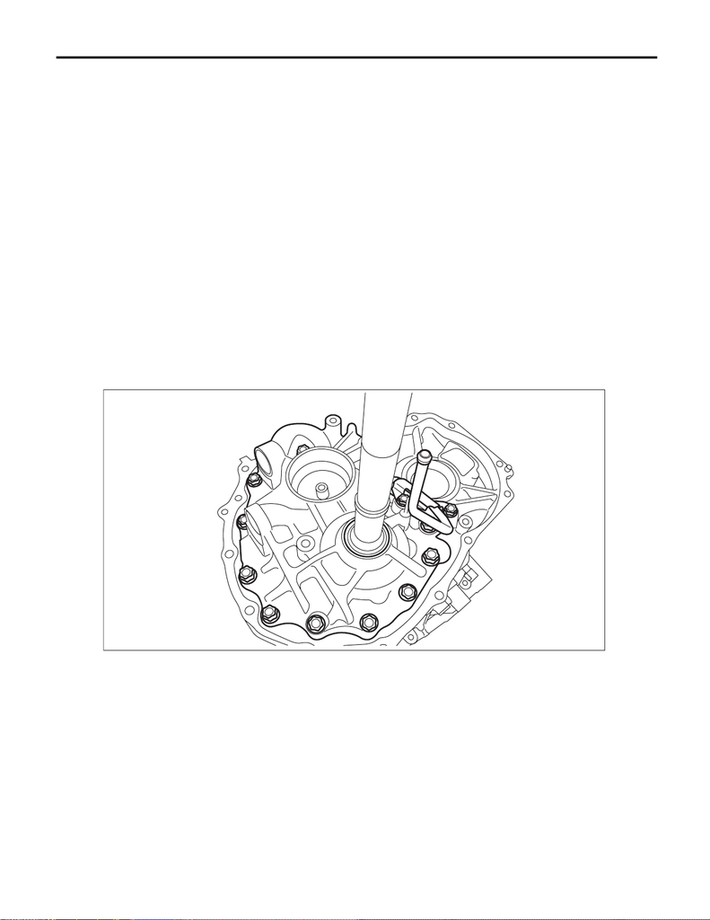

CVT(TR690)-244

Drive Pinion Shaft Assembly

CONTINUOUSLY VARIABLE TRANSMISSION

43.Drive Pinion Shaft Assembly

A: REMOVAL

1) Remove the transmission assembly from the vehicle. <Ref. to CVT(TR690)-56, REMOVAL, Automatic

Transmission Assembly.>

2) Remove the air breather hose. <Ref. to CVT(TR690)-136, REMOVAL, Air Breather Hose.>

3) Remove the oil pan and control valve body. <Ref. to CVT(TR690)-112, REMOVAL, Control Valve Body.>

4) Remove the transmission harness. <Ref. to CVT(TR690)-123, REMOVAL, Transmission Harness.>

5) Remove the extension case. <Ref. to CVT(TR690)-142, REMOVAL, Extension Case.>

6) Remove the rear drive shaft. <Ref. to CVT(TR690)-146, REMOVAL, Rear Drive Shaft.>

7) Remove the transfer clutch assembly. <Ref. to CVT(TR690)-151, REMOVAL, Transfer Clutch.>

8) Remove the center differential carrier. <Ref. to CVT(TR690)-154, REMOVAL, Center Differential Carrier.>

9) Remove the transfer reduction driven gear assembly. <Ref. to CVT(TR690)-158, REMOVAL, Transfer Re-

duction Driven Gear.>

10) Remove the intermediate case. <Ref. to CVT(TR690)-165, REMOVAL, Intermediate Case.>

11) Remove the forward clutch assembly. <Ref. to CVT(TR690)-181, REMOVAL, Forward Clutch Assem-

bly.>

12) Remove the transmission case. <Ref. to CVT(TR690)-212, REMOVAL, Transmission Case.>

13) Remove the primary pulley, secondary pulley and variator chain. <Ref. to CVT(TR690)-228, REMOVAL,

Primary Pulley and Secondary Pulley.>

14) Using the ST, remove the drive pinion retainer and lubrication pipe.

ST 18270KA020 SOCKET (E20)

AT-05348

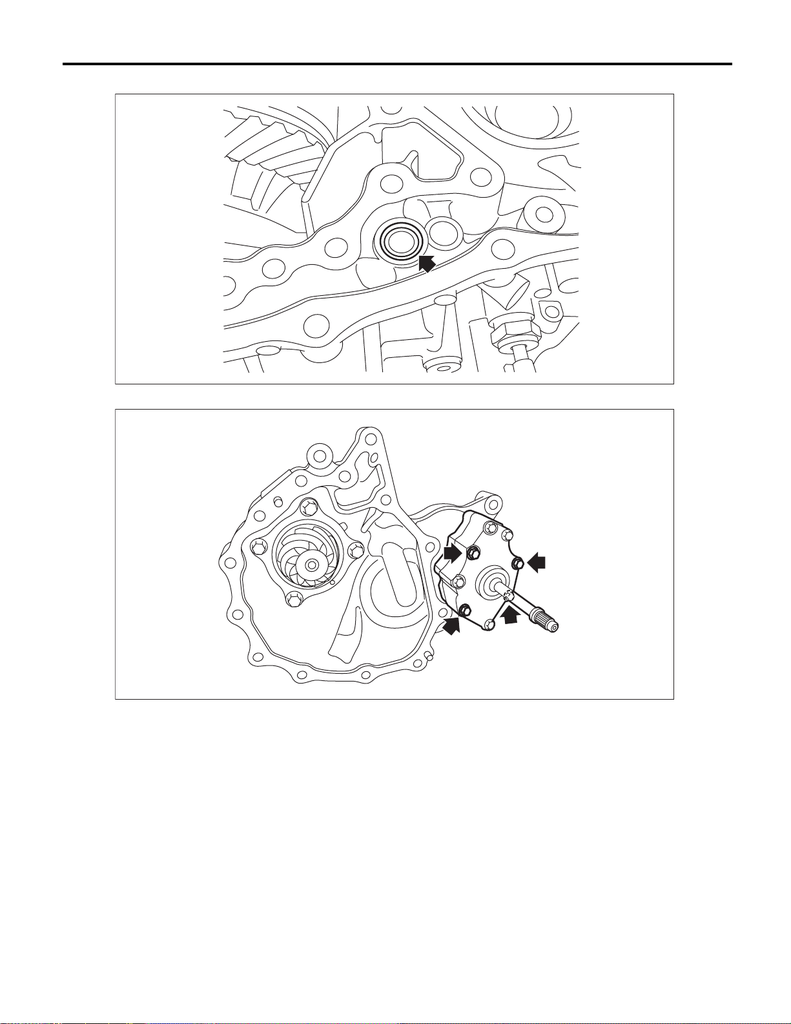

CVT(TR690)-245

Drive Pinion Shaft Assembly

CONTINUOUSLY VARIABLE TRANSMISSION

15) Remove the O-rings.

16) Remove the oil pump and the plate.

AT-05350

AT-05349

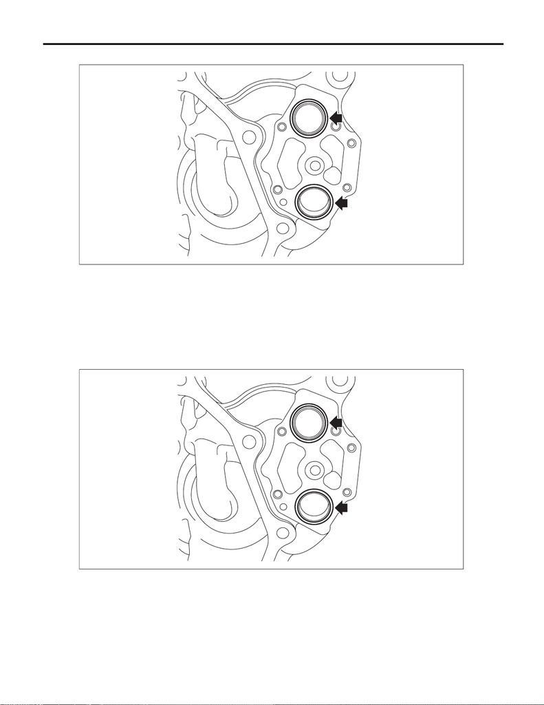

CVT(TR690)-246

Drive Pinion Shaft Assembly

CONTINUOUSLY VARIABLE TRANSMISSION

17) Remove the O-rings.

B: INSTALLATION

1) Clean the mating surface of drive pinion retainer and converter case.

2) Adjust the backlash and tooth contact between drive pinion shaft assembly and the front differential side

gear. <Ref. to CVT(TR690)-258, ADJUSTMENT, Drive Pinion Shaft Assembly.>

3) Install the O-ring for oil pump to drive pinion retainer.

NOTE:

• Use new O-rings.

• Apply CVTF to the O-rings.

AT-05351

AT-05351

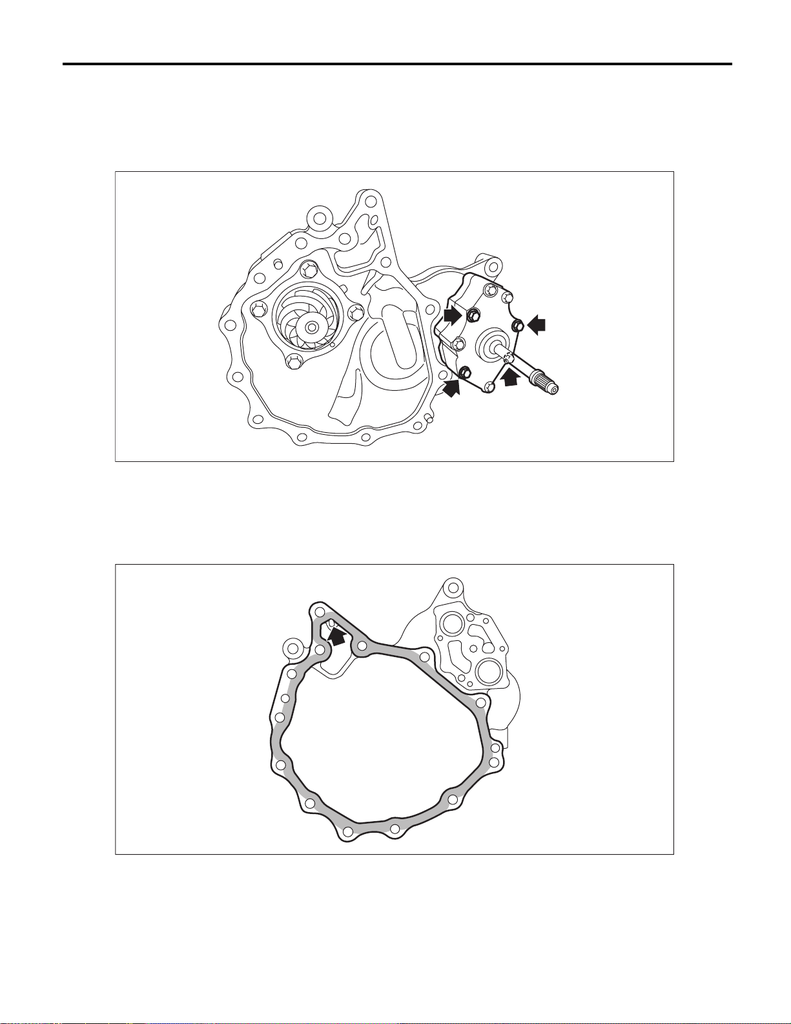

CVT(TR690)-247

Drive Pinion Shaft Assembly

CONTINUOUSLY VARIABLE TRANSMISSION

4) Install the plate and the oil pump.

NOTE:

Apply CVTF to the bolt.

Tightening torque:

8.5 N·m (0.9 kgf-m, 6.3 ft-lb)

5) Apply liquid gasket seamlessly to the mating surface of drive pinion retainer.

NOTE:

Be careful not to block the arrowed hole when applying liquid gasket.

Liquid gasket:

THREE BOND 1215B or equivalent

AT-05349

AT-05353

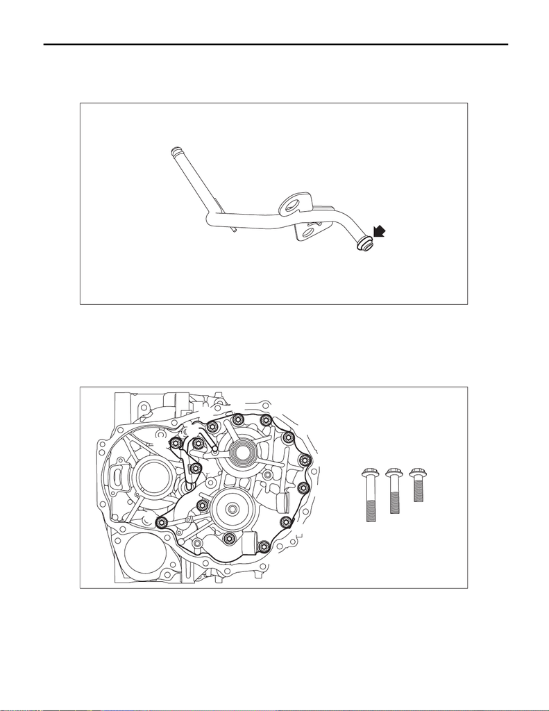

CVT(TR690)-248

Drive Pinion Shaft Assembly

CONTINUOUSLY VARIABLE TRANSMISSION

6) Install the O-ring to the lubrication pipe.

NOTE:

• Use new O-rings.

• Apply CVTF to the O-rings.

7) Install the drive pinion retainer and lubrication pipe to converter case and tighten the bolt using the ST.

ST 18270KA020 SOCKET (E20)

NOTE:

Do not confuse the three different-length bolts when installing.

Tightening torque:

43 N·m (4.4 kgf-m, 31.7 ft-lb)

AT-05354

AT-07900

(A) (B)

(B)

(B)

(B)

(B)

(C)

(C)

(C)

(C)

(C)

(A)

(A)

(A)

(A)

(A)

(A)

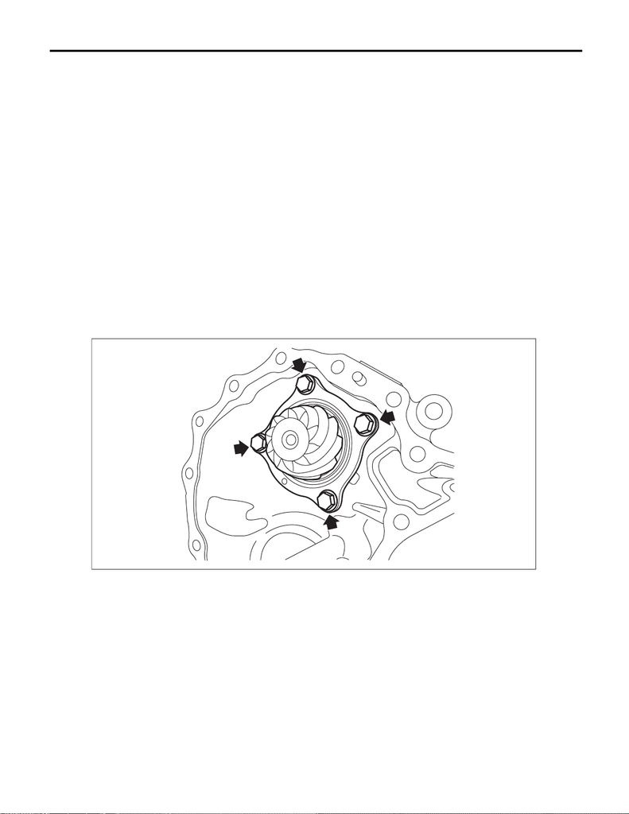

CVT(TR690)-249

Drive Pinion Shaft Assembly

CONTINUOUSLY VARIABLE TRANSMISSION

8) Install the primary pulley, secondary pulley and variator chain. <Ref. to CVT(TR690)-232, INSTALLA-

TION, Primary Pulley and Secondary Pulley.>

9) Install the transmission case. <Ref. to CVT(TR690)-214, INSTALLATION, Transmission Case.>

10) Install the forward clutch assembly. <Ref. to CVT(TR690)-182, INSTALLATION, Forward Clutch Assem-

bly.>

11) Install the intermediate case. <Ref. to CVT(TR690)-166, INSTALLATION, Intermediate Case.>

12) Install the transfer reduction driven gear assembly. <Ref. to CVT(TR690)-158, INSTALLATION, Transfer

Reduction Driven Gear.>

13) Install the center differential carrier. <Ref. to CVT(TR690)-155, INSTALLATION, Center Differential Car-

rier.>

14) Install the transfer clutch assembly. <Ref. to CVT(TR690)-151, INSTALLATION, Transfer Clutch.>

15) Install the rear drive shaft. <Ref. to CVT(TR690)-146, INSTALLATION, Rear Drive Shaft.>

16) Install the extension case. <Ref. to CVT(TR690)-143, INSTALLATION, Extension Case.>

17) Install the transmission harness. <Ref. to CVT(TR690)-125, INSTALLATION, Transmission Harness.>

18) Install the oil pan and control valve body. <Ref. to CVT(TR690)-116, INSTALLATION, Control Valve

Body.>

19) Install the air breather hose. <Ref. to CVT(TR690)-136, INSTALLATION, Air Breather Hose.>

20) Install the transmission assembly to the vehicle. <Ref. to CVT(TR690)-69, INSTALLATION, Automatic

Transmission Assembly.>

C: DISASSEMBLY

1) Remove the drive pinion assembly.

AT-05352

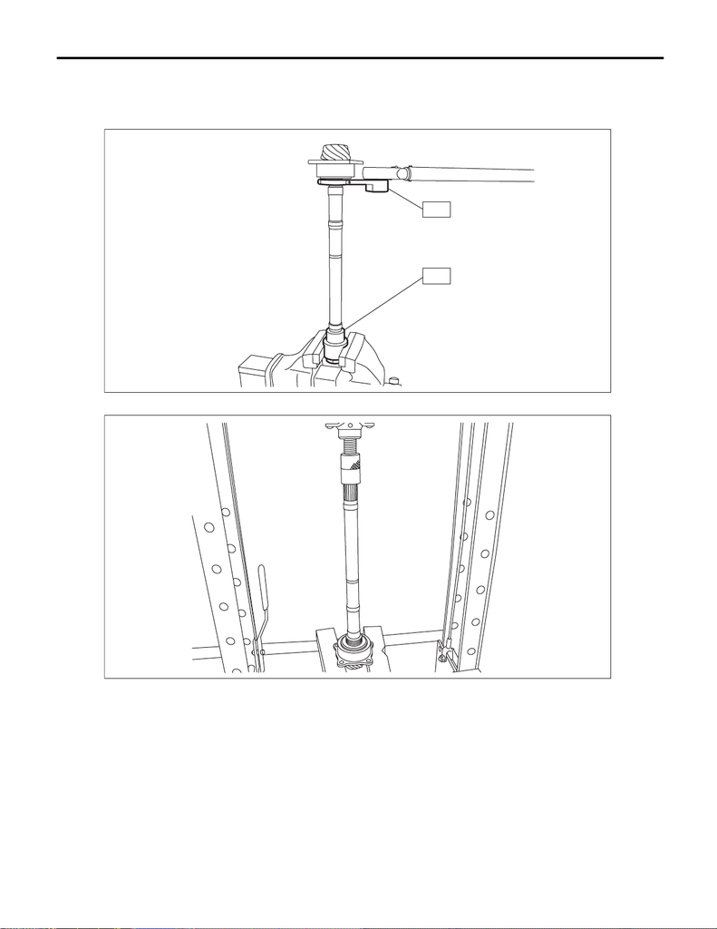

CVT(TR690)-250

Drive Pinion Shaft Assembly

CONTINUOUSLY VARIABLE TRANSMISSION

2) Flatten the tab of the lock nut.

3) Using ST1 and ST2, fix at the spline portion of drive pinion shaft to remove the lock nut.

ST1 18621AA000 WRENCH

ST2 18667AA010 HOLDER

4) Remove the taper roller bearing and outer race from drive pinion shaft.

AT-05356

ST1

ST2

AT-05357

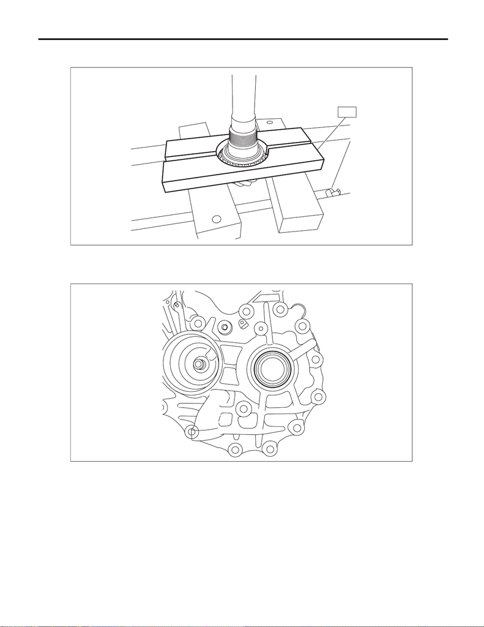

CVT(TR690)-251

Drive Pinion Shaft Assembly

CONTINUOUSLY VARIABLE TRANSMISSION

5) Remove the inner bearing inner race from the drive pinion shaft using ST.

ST 498077000 REMOVER

6) Remove the two oil seals using a screwdriver wrapped with cloth etc.

CAUTION:

Do not damage the fitting surface of drive pinion bearing.

7) Remove the plug from drive pinion retainer.

AT-05358

ST

AT-05359

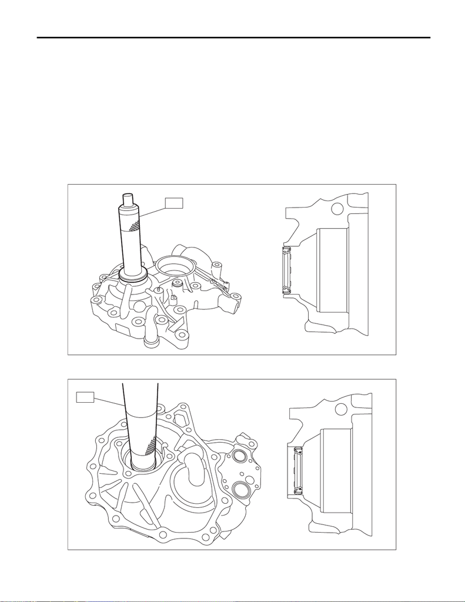

CVT(TR690)-252

Drive Pinion Shaft Assembly

CONTINUOUSLY VARIABLE TRANSMISSION

D: ASSEMBLY

1) Install the O-ring to plug and install the plug to drive pinion retainer.

NOTE:

• Use new O-rings.

• Apply CVTF to the O-ring.

Tightening torque:

25 N·m (2.5 kgf-m, 18.4 ft-lb)

2) Using the ST, install the oil seal to drive pinion retainer.

NOTE:

• Apply CVTF to the oil seal press-fitting surface and lip.

• Install the oil seal in the correct direction.

Pulley side

ST 18657AA020 OIL SEAL INSTALLER

Front differential side

ST 499277100 INSTALLER

AT-05360

ST

AT-05361

ST

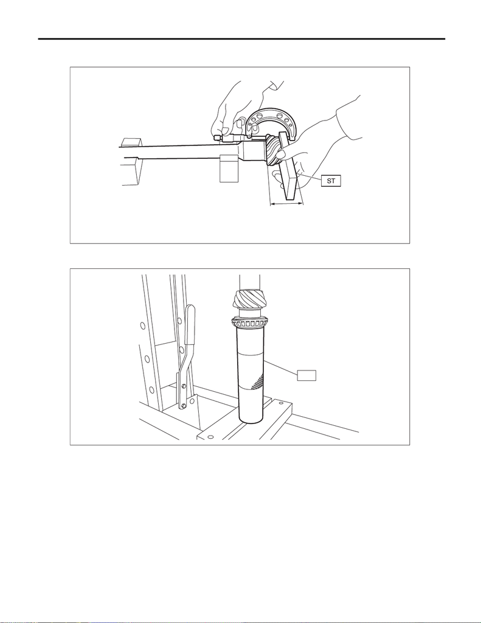

CVT(TR690)-253

Drive Pinion Shaft Assembly

CONTINUOUSLY VARIABLE TRANSMISSION

3) Measure the dimension “A” of drive pinion shaft.

ST 398643600 GAUGE

4) Press-fit the new taper roller bearing front side inner race using the ST.

ST 499277200 INSTALLER

AT-05362

A

AT-05363

ST

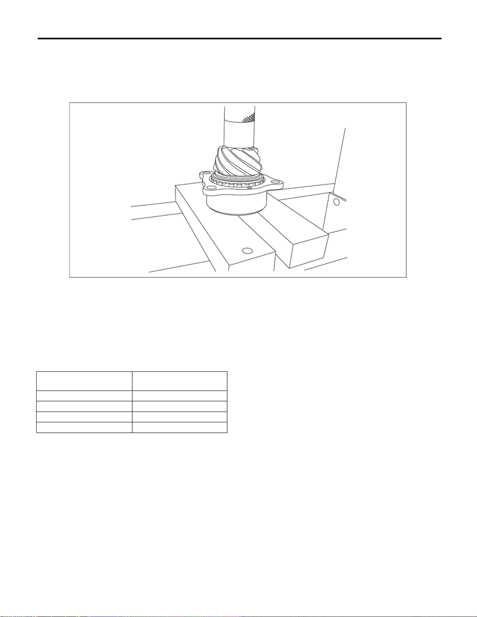

CVT(TR690)-254

Drive Pinion Shaft Assembly

CONTINUOUSLY VARIABLE TRANSMISSION

5) Press-fit the new taper roller bearing rear side inner race and outer race together.

CAUTION:

Damage may result if too much force is applied to the roller bearing.

NOTE:

Press in to a position where the bearing rotates smoothly without play.

6) Tighten a new lock nut using the ST.

Using the following formula, calculate the torque for a torque wrench.

T2 = L2/(L1 + L2) × T1

T1: 130 N·m (13.3 kgf-m, 95.9 ft-lb)

[Required torque setting]

T2: Tightening torque

L1: ST1 length 0.1 m (3.94 in)

L2: Torque wrench length

Example:

Torque wrench length

m (in)

Tightening torque

N·m (kgf-m, ft-lb)

0.4 (15.75) 104 (10.6, 76.7)

0.45 (17.72) 106 (10.8, 78.2)

0.5 (19.69) 108 (11.0, 79.7)

0.55 (21.65) 110 (11.2, 81.1)

AT-05364

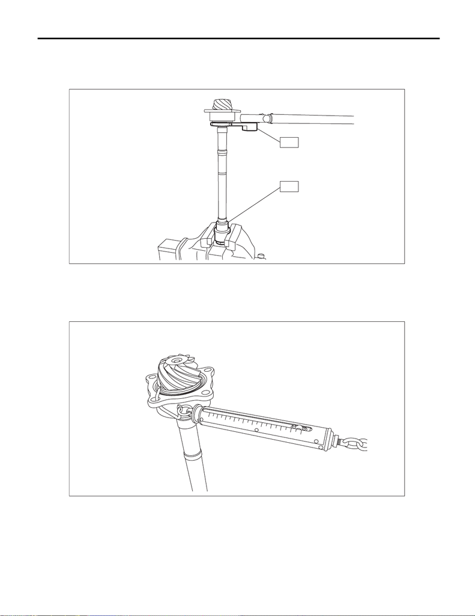

CVT(TR690)-255

Drive Pinion Shaft Assembly

CONTINUOUSLY VARIABLE TRANSMISSION

ST1 18621AA000 WRENCH

ST2 18667AA010 HOLDER

NOTE:

Tighten the lock nut while directly aligning ST1 and torque wrench.

7) Apply differential gear oil to roller of bearing and rotate the bearing several times.

8) Measure the starting torque of the bearing. Make sure the starting torque is within the specified range. If

the torque is not within specified range, replace the roller bearing.

AT-05356

ST1

ST2

AT-05365

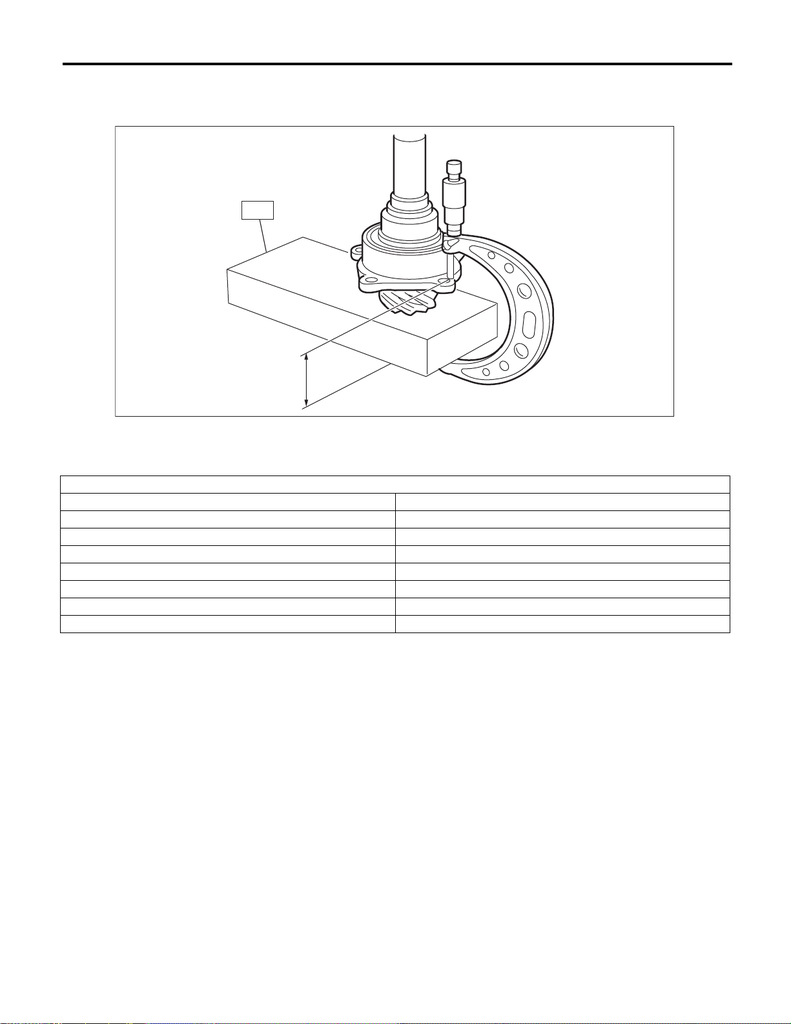

CVT(TR690)-256

Drive Pinion Shaft Assembly

CONTINUOUSLY VARIABLE TRANSMISSION

9) Crimp the lock nut in 2 locations.

10) Measure the dimension “B” of the drive pinion shaft.

ST 398643600 GAUGE

11) Obtain thickness “t” mm (in) of the drive pinion shim.

t = 6.55±0.1225 – (B – A)

12) Select three or less shims from following table.

Drive pinion shim

Part No. Thickness mm (in)

31451AA050 0.150 (0.0059)

31451AA060 0.175 (0.0069)

31451AA070 0.200 (0.0079)

31451AA080 0.225 (0.0089)

31451AA090 0.250 (0.0098)

31451AA100 0.275 (0.0108)

31451AA240 0.300 (0.0118)

AT-07901

B

ST

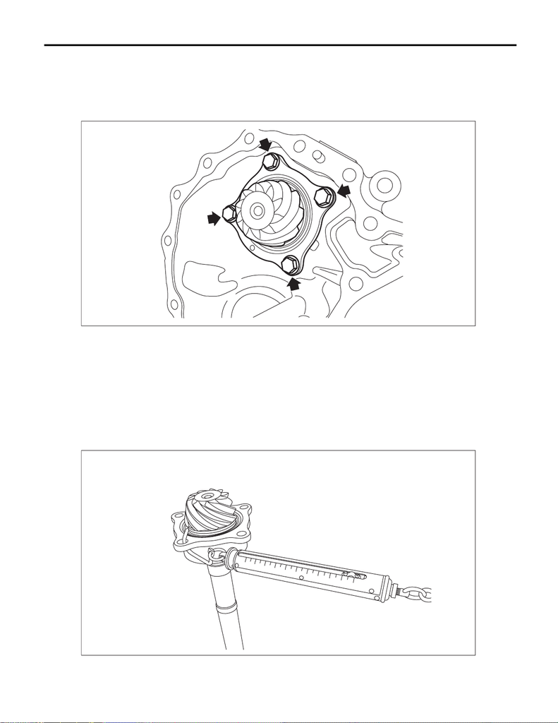

CVT(TR690)-257

Drive Pinion Shaft Assembly

CONTINUOUSLY VARIABLE TRANSMISSION

13) Install the shims selected for drive pinion retainer and drive pinion shaft assembly.

NOTE:

Be careful not to bend the shim.

Tightening torque:

70 N·m (7.1 kgf-m, 51.6 ft-lb)

E: INSPECTION

• Make sure that all component parts are free of scratches, holes and other faults.

• Check the tooth contact. <Ref. to CVT(TR690)-258, ADJUSTMENT, Drive Pinion Shaft Assembly.>

• Apply CVTF to bearing and rotate the bearing to check for noise or dragging etc.

• Check the bearing preload of drive pinion shaft.

CAUTION:

Before measuring, apply differential gear oil to roller of bearing and rotate the bearing several times.

AT-05352

AT-05365

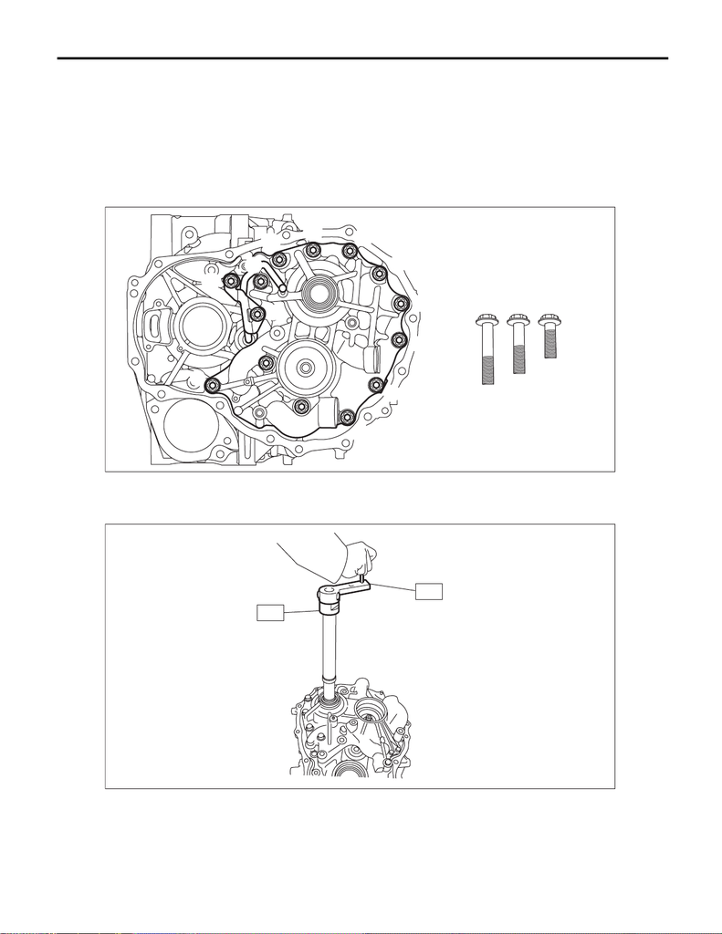

CVT(TR690)-258

Drive Pinion Shaft Assembly

CONTINUOUSLY VARIABLE TRANSMISSION

F: ADJUSTMENT

1) Remove the liquid gasket from the mating surface completely.

2) Using the ST, install the drive pinion retainer to converter case.

ST 18270KA020 SOCKET (E20)

NOTE:

Do not confuse the three different-length bolts when installing.

Tightening torque:

43 N·m (4.4 kgf-m, 31.7 ft-lb)

3) Rotate the drive pinion several times using ST1 and ST2.

ST1 18667AA010 HOLDER

ST2 499787700 WRENCH

AT-07900

(A) (B)

(B)

(B)

(B)

(B)

(C)

(C)

(C)

(C)

(C)

(A)

(A)

(A)

(A)

(A)

(A)

AT-05394

ST2

ST1

[figure not shown]

CVT(TR690)-259

Drive Pinion Shaft Assembly

CONTINUOUSLY VARIABLE TRANSMISSION

4) Adjust the drive pinion and hypoid driven gear backlash. <Ref. to CVT(TR690)-280, ADJUSTMENT, Front

Differential Assembly.>

5) Using the ST, remove the drive pinion retainer from converter case.

ST 18270KA020 SOCKET (E20)

6) Apply lead-free red dye evenly on the both sides of three to four teeth of the hypoid driven gear. Then in-

stall the drive pinion retainer and rotate the drive pinion in both directions several times. Remove the drive

pinion retainer and check the tooth contact pattern.

If the teeth contact is inappropriate, adjust the backlash or thickness of the shim. <Ref. to CVT(TR690)-280,

ADJUSTMENT, Front Differential Assembly.>

NOTE:

After correction, wipe off the lead-free red dye.

• Correct tooth contact

Check item: Tooth contact surface is slightly shifted toward the toe side under a no-load condition.

(When driving, it moves towards the heel side.)

(A) Toe side

(B) Heel side

AT-07902

(A)

(B)

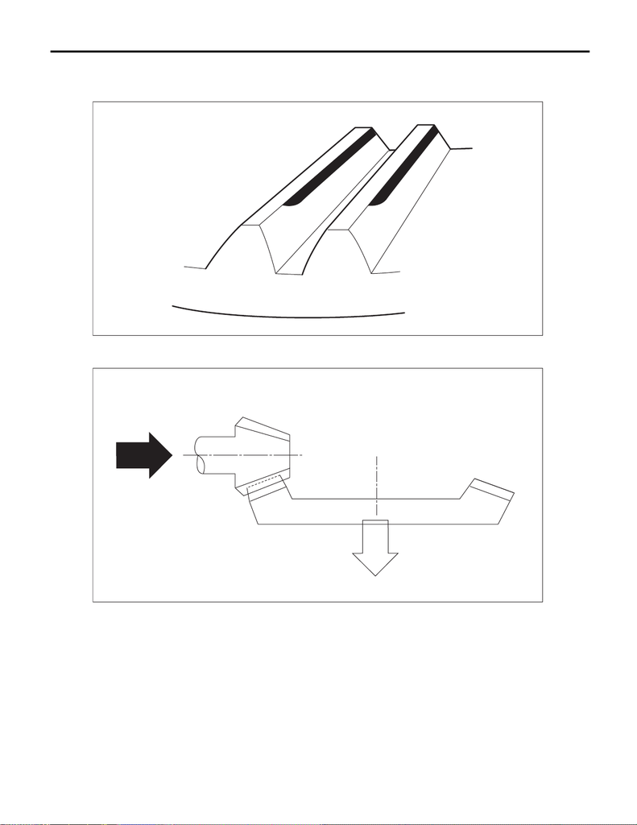

CVT(TR690)-260

Drive Pinion Shaft Assembly

CONTINUOUSLY VARIABLE TRANSMISSION

• Face contact

Check item: Backlash is too large.

Contact pattern

Corrective action: Increase thickness of pinion height adjusting washer according to the procedure for bring-

ing drive pinion close to hypoid driven gear side.

AT-05368

AT-05369

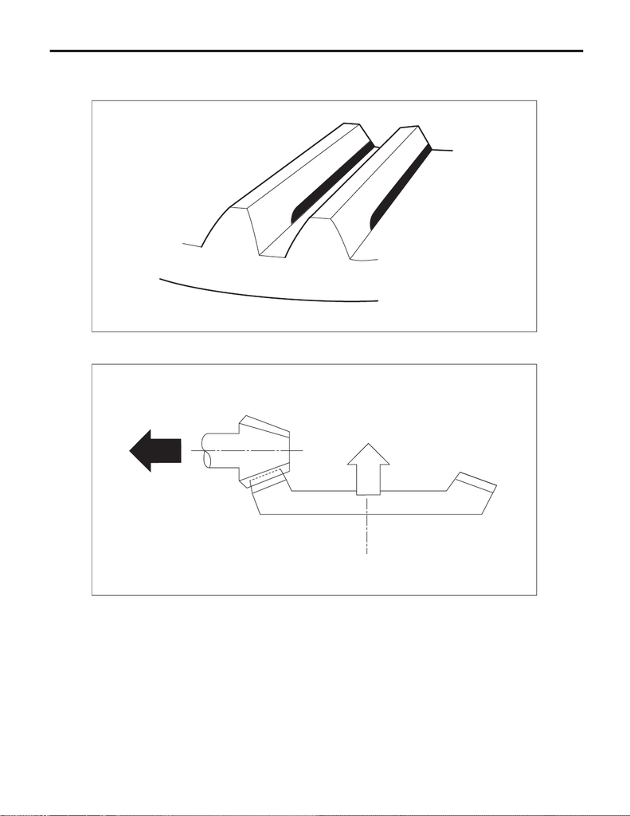

CVT(TR690)-261

Drive Pinion Shaft Assembly

CONTINUOUSLY VARIABLE TRANSMISSION

• Flank contact

Check item: Backlash is too small.

Contact pattern

Corrective action: Reduce the thickness of pinion height adjusting washer according to the procedure for

bringing drive pinion away from hypoid driven gear.

AT-05370

AT-05371

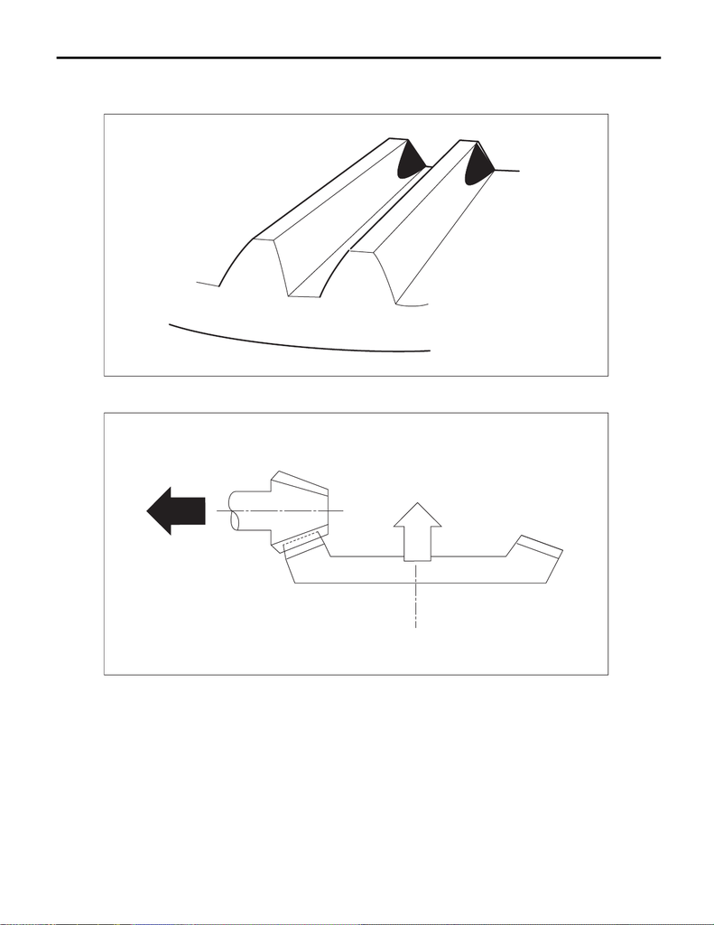

CVT(TR690)-262

Drive Pinion Shaft Assembly

CONTINUOUSLY VARIABLE TRANSMISSION

• Toe contact (inside contact)

Check item: Teeth contact area is too small.

Contact pattern

Corrective action: Reduce the thickness of pinion height adjusting washer according to the procedure for

bringing drive pinion away from hypoid driven gear side.

AT-05372

AT-05371

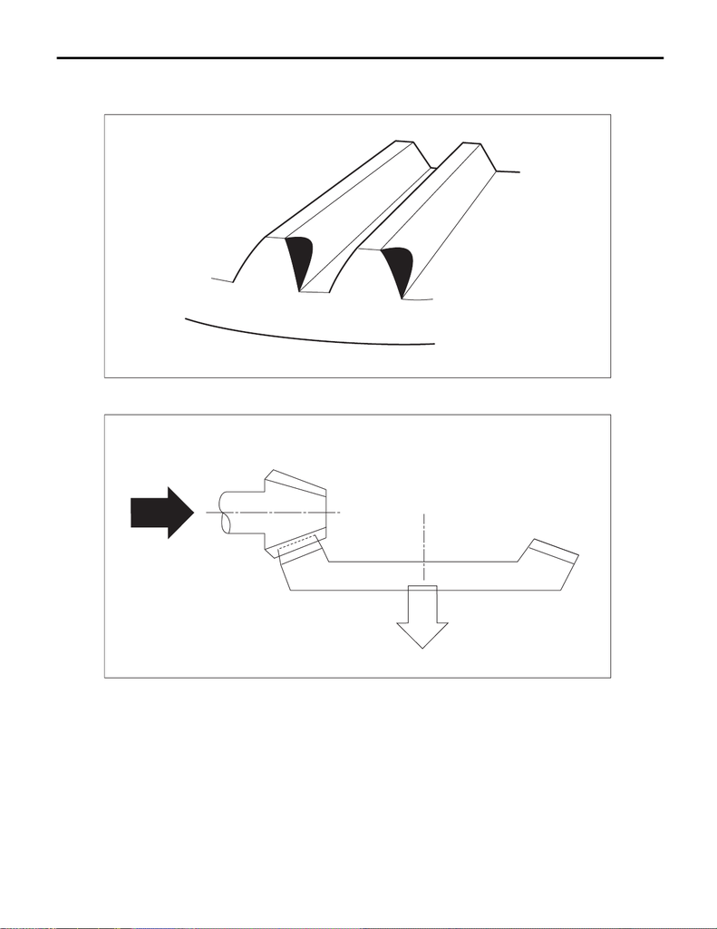

CVT(TR690)-263

Drive Pinion Shaft Assembly

CONTINUOUSLY VARIABLE TRANSMISSION

• Heel contact (outside end contact)

Check item: Teeth contact area is too small.

Contact pattern

Corrective action: Increase the thickness of the pinion height adjusting washer according to the procedures

for moving the drive pinion closer to the hypoid driven gear.

AT-05373

AT-05369

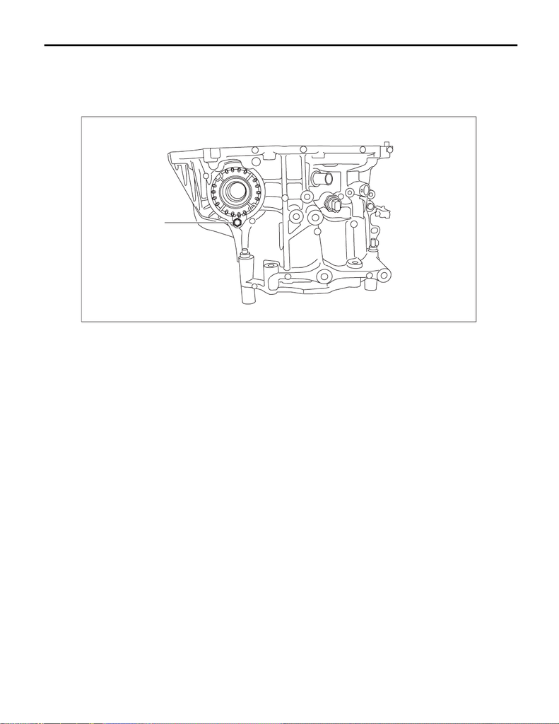

CVT(TR690)-264

Drive Pinion Shaft Assembly

CONTINUOUSLY VARIABLE TRANSMISSION

7) If tooth contact is correct, mark the differential side retainer position and loosen. After fitting a new O-ring

and oil seal, screw in the differential side retainer to the marked position.

8) Tighten the lock plate with specified torque.

Tightening torque:

25 N·m (2.5 kgf-m, 18.4 ft-lb)

(A) Lock plate

(A)

AT-07903